# Project 3: Investigating TMDb movie data

- Introduction
- Data Wrangling
- Exploratory Data Analysis
- Conclusions

## Introduction

The data set analyzed in this projects contains information about 10,000 movies collected from The Movie Database (TMDb), including user ratings and revenue. I will answer the following questions:

1. What are the Top-10 rates movies of all time?

2. Which genres are most popular from year to year?

3. Which genre is the most profitable one?

4. Who is the most popular actor?

5. Generating a wordcloud from keywords

6. What kinds of properties are associated with movies that have high revenues?

7. Does sex really sell?

```python
# import statements
import pandas as pd
import matplotlib.pyplot as plt
from matplotlib.ticker import FormatStrFormatter
import seaborn as sns
from wordcloud import WordCloud
%matplotlib inline
```

## Data Wrangling

### General Properties

```python
# loading data
df = pd.read_csv('tmdb-movies.csv')
```

```python
df.shape
```

```
(10866, 21)
```

```python
# inspecting datatypes
df.dtypes
```

```
id                        int64
imdb_id                  object
popularity              float64
budget                    int64
revenue                   int64
original_title           object
cast                     object
homepage                 object
director                 object
tagline                  object
keywords                 object
overview                 object
runtime                   int64
genres                   object
production_companies     object
release_date             object
vote_count                int64
vote_average            float64
release_year              int64
budget_adj              float64
revenue_adj             float64
dtype: object
```

```python
# checking for duplicates
df.duplicated().sum()
```

```
1
```

```python
# removing duplicates
df.drop_duplicates(inplace=True)
```

```python
# print a few lines of the dataset
df.head(3)
```

|  | id | imdb_id | popularity | budget | revenue | original_title | cast | homepage | director | tagline | ... | overview | runtime | genres | production_companies | release_date | vote_count | vote_average | release_year | budget_adj | revenue_adj |
| --- | --- | --- | --- | --- | --- | --- | --- | --- | --- | --- | --- | --- | --- | --- | --- | --- | --- | --- | --- | --- | --- |
| 0 | 135397 | tt0369610 | 32.985763 | 150000000 | 1513528810 | Jurassic World | Chris Pratt\|Bryce Dallas Howard\|Irrfan Khan\|Vi... | http://www.jurassicworld.com/ | Colin Trevorrow | The park is open. | ... | Twenty-two years after the events of Jurassic ... | 124 | Action\|Adventure\|Science Fiction\|Thriller | Universal Studios\|Amblin Entertainment\|Legenda... | 6/9/15 | 5562 | 6.5 | 2015 | 1.379999e+08 | 1.392446e+09 |
| 1 | 76341 | tt1392190 | 28.419936 | 150000000 | 378436354 | Mad Max: Fury Road | Tom Hardy\|Charlize Theron\|Hugh Keays-Byrne\|Nic... | http://www.madmaxmovie.com/ | George Miller | What a Lovely Day. | ... | An apocalyptic story set in the furthest reach... | 120 | Action\|Adventure\|Science Fiction\|Thriller | Village Roadshow Pictures\|Kennedy Miller Produ... | 5/13/15 | 6185 | 7.1 | 2015 | 1.379999e+08 | 3.481613e+08 |
| 2 | 262500 | tt2908446 | 13.112507 | 110000000 | 295238201 | Insurgent | Shailene Woodley\|Theo James\|Kate Winslet\|Ansel... | http://www.thedivergentseries.movie/#insurgent | Robert Schwentke | One Choice Can Destroy You | ... | Beatrice Prior must confront her inner demons ... | 119 | Adventure\|Science Fiction\|Thriller | Summit Entertainment\|Mandeville Films\|Red Wago... | 3/18/15 | 2480 | 6.3 | 2015 | 1.012000e+08 | 2.716190e+08 |

3 rows × 21 columns

### Data Cleaning

> We can see that in the **cast**, **genres** and **production_companies** and the **keywords** columns, there are **multiple values in one cell, seperated by "|"**. This format is not useful for analysis. In the next steps I will split the dataset into 4 seperate tables:
> - **df_cast**: Holding information the movie cast
> - **df_genre**: information about the movie genres
> - **df_production**: information about the production companies of a certain movie
> - **df_keywords**: holding all the different keywords of a movie
> - **df**: holfing all the remaining information

> By doing so, we will "normalize" the dataset and transform it into a "relational database"-like structure. The "id" column will serve as the primary key to identify each movie and combine information across the 5 tables. I will define a fuction called **seperate_and_melt()** which will use on each of the 4 columns to seperate the data.

```python
# defining the fuction
def seperate_and_melt(df, column):
    # create new df with the id in one column and each of the cast/genre/production companies in a seperate column
    df_new = pd.concat([df['id'], column.str.split("|", expand=True)], axis=1)
    # melt this df, so that there is only an 'id'column and a 'cast/genre/company' column
    df_new = pd.melt(df_new, id_vars=['id'], value_name = column.name)
    # drop variable column
    df_new.drop(['variable'], axis=1, inplace=True)
    # drop none rows
    df_new.dropna(inplace=True)
    return df_new
```

```python
# using the function on the 3 columns to get seperate data frames
df_cast = seperate_and_melt(df, df['cast'])
df_genre = seperate_and_melt(df, df['genres'])
df_production = seperate_and_melt(df, df['production_companies'])
df_keywords = seperate_and_melt(df, df['keywords'])
```

```python
# now we can delete these rows from the original df, so it will only hold useful information
df.drop(['cast', 'genres', 'production_companies', 'keywords'], axis=1, inplace=True)
```

> **Now our data is organized in 4 tables which look this way:**

```python
df_cast.head(3)
```

|  | id | cast |
| --- | --- | --- |
| 0 | 135397 | Chris Pratt |
| 1 | 76341 | Tom Hardy |
| 2 | 262500 | Shailene Woodley |

```python
df_genre.head(3)
```

|  | id | genres |
| --- | --- | --- |
| 0 | 135397 | Action |
| 1 | 76341 | Action |
| 2 | 262500 | Adventure |

```python
df_production.head(3)
```

|  | id | production_companies |
| --- | --- | --- |
| 0 | 135397 | Universal Studios |
| 1 | 76341 | Village Roadshow Pictures |
| 2 | 262500 | Summit Entertainment |

```python
df.head(3)
```

|  | id | imdb_id | popularity | budget | revenue | original_title | homepage | director | tagline | overview | runtime | release_date | vote_count | vote_average | release_year | budget_adj | revenue_adj |
| --- | --- | --- | --- | --- | --- | --- | --- | --- | --- | --- | --- | --- | --- | --- | --- | --- | --- |
| 0 | 135397 | tt0369610 | 32.985763 | 150000000 | 1513528810 | Jurassic World | http://www.jurassicworld.com/ | Colin Trevorrow | The park is open. | Twenty-two years after the events of Jurassic ... | 124 | 6/9/15 | 5562 | 6.5 | 2015 | 1.379999e+08 | 1.392446e+09 |
| 1 | 76341 | tt1392190 | 28.419936 | 150000000 | 378436354 | Mad Max: Fury Road | http://www.madmaxmovie.com/ | George Miller | What a Lovely Day. | An apocalyptic story set in the furthest reach... | 120 | 5/13/15 | 6185 | 7.1 | 2015 | 1.379999e+08 | 3.481613e+08 |
| 2 | 262500 | tt2908446 | 13.112507 | 110000000 | 295238201 | Insurgent | http://www.thedivergentseries.movie/#insurgent | Robert Schwentke | One Choice Can Destroy You | Beatrice Prior must confront her inner demons ... | 119 | 3/18/15 | 2480 | 6.3 | 2015 | 1.012000e+08 | 2.716190e+08 |

## Exploratory Data Analysis

### 1. What are the Top-10 rated movies in the dataset?

We want to find the 10 movies with the highest **vote_average**. Because there are also movies in the dataset which revieved a high average rating, but the number of ratings is very low, we will limit our list to movies which were rated sufficiently often (> mean of vount_count).

```python
df['vote_count'].mean() # calculating the avg number of votes
```

```
217.39963184537507
```

```python
top_10 = df.query('vote_count > 217').nlargest(10, 'vote_average').reset_index()
top_10[['id','original_title', 'vote_average']]
```

|  | id | original_title | vote_average |
| --- | --- | --- | --- |
| 0 | 278 | The Shawshank Redemption | 8.4 |
| 1 | 238 | The Godfather | 8.3 |
| 2 | 244786 | Whiplash | 8.2 |
| 3 | 550 | Fight Club | 8.1 |
| 4 | 155 | The Dark Knight | 8.1 |
| 5 | 680 | Pulp Fiction | 8.1 |
| 6 | 13 | Forrest Gump | 8.1 |
| 7 | 240 | The Godfather: Part II | 8.1 |
| 8 | 424 | Schindler's List | 8.1 |
| 9 | 150540 | Inside Out | 8.0 |

### 2. Which genres are most popular from year to year?

To answer this question, we need to join the **df_genre** table with the general **df** table using pandas **merge()** fuction. Then we will group by release_year and genre and calculate the average popularity per genre.

```python
# SELECT df_genre.genre, df.release_year
# FROM df_genre
# JOIN df ON id
genre_year_popularity = df_genre.merge(df,  on='id')[['release_year', 'genres', 'popularity']]
genre_year_popularity = genre_year_popularity.groupby(['release_year', 'genres'])['popularity'].mean()
genre_year_popularity
```

```
release_year  genres
1960          Action             0.590724
              Adventure          0.700981
              Comedy             0.396000
              Crime              0.346480
              Drama              0.566305
              Family             0.278064
              Fantasy            0.428247
              Foreign            0.194948
              History            0.412364
              Horror             0.591450
              Music              0.423531
              Romance            0.541227
              Science Fiction    0.327905
              Thriller           0.811910
              War                0.225863
              Western            0.567759
1961          Action             0.365913
              Adventure          0.767323
              Animation          2.631987
              Comedy             0.679838
              Crime              0.806519
              Drama              0.432233
              Family             0.755722
              Fantasy            0.154073
              Foreign            0.113651
              History            0.334463
              Horror             0.254578
              Music              0.564749
              Mystery            0.712793
              Romance            0.426036
                                   ...
2014          Fantasy            1.829351
              History            1.076321
              Horror             0.483898
              Music              0.652112
              Mystery            1.013722
              Romance            0.629171
              Science Fiction    2.294452
              TV Movie           0.296038
```

[output cut: 8 more lines]

```
              Documentary        0.190483
              Drama              0.937877
              Family             1.369038
              Fantasy            1.740228
              History            1.007905
              Horror             0.476670
              Music              0.635101
              Mystery            1.214847
              Romance            0.948865
              Science Fiction    2.245603
              TV Movie           0.260574
              Thriller           1.401877
              War                1.284511
              Western            3.178796
Name: popularity, Length: 1049, dtype: float64
```

Now, we will create a line plot using matplotlib:

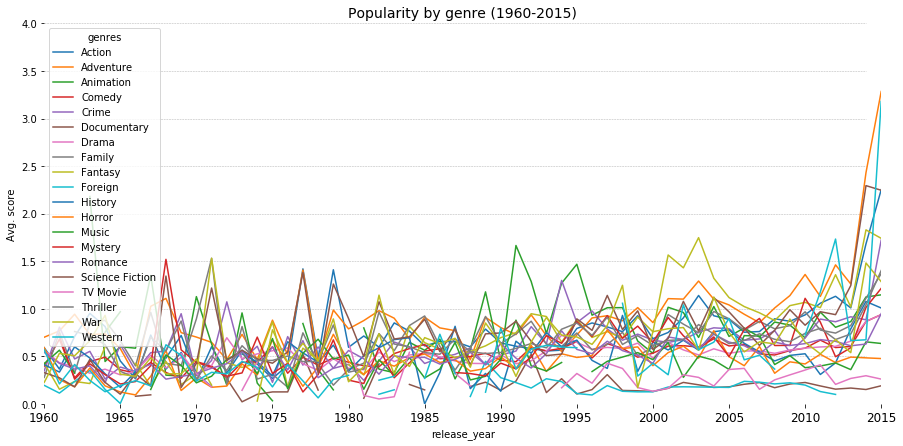

```python
# creating the lineplot
fig, ax = plt.subplots(figsize=(15,7))
plt.title("Popularity by genre (1960-2015)", fontsize=14)
plt.ylabel("Avg. score") #for documentation regarding the popularity metric visit: https://developers.themoviedb.org/3/getting-started/popularity
# Removing frame lines
ax.spines["top"].set_visible(False)
ax.spines["bottom"].set_visible(False)
ax.spines["right"].set_visible(False)
ax.spines["left"].set_visible(False)

# Limit the range of the plot to only where the data is.
# Avoid unnecessary whitespace.
plt.ylim(0, 4)
plt.xlim(1960, 2015)

# Adjusting axis ticks
ax.yaxis.set_major_formatter(FormatStrFormatter('%.1f'))
plt.xticks(range(1960, 2016, 5), fontsize=12)

# Axis ticklines across the data for readability
for y in range(0, 9, 1):
    plt.plot(range(1960, 2015), [y/2] * len(range(1960, 2015)), "--", lw=0.5, color="black", alpha=0.3)

genre_year_popularity.unstack().plot(ax=ax);
```

> We can see a couple of interesting things in this chart. Approximately between 2000 and 2005 there is a spike in the popularity of Fantasy movies. Also, there is a sharp increase in popularity of Adventure and Western movies in the last years. Western movies?! How odd. **Lets find out which were the most popular Western in 2015:**

```python
western_2015 = df.merge(df_genre, on='id').query('genres == "Western" & release_year == 2015').nlargest(3, 'popularity').reset_index()[['original_title', 'genres', 'popularity']]
western_2015
```

|  | original_title | genres | popularity |
| --- | --- | --- | --- |
| 0 | The Revenant | Western | 9.110700 |
| 1 | The Hateful Eight | Western | 5.898400 |
| 2 | Slow West | Western | 1.329702 |

> As you can see, in 2015, **The Revenant** was released and it was hugely popular.

### 3. Which genre is the most profitable one for production companies?

Profitability here is defined as the return on the used budget (revenue / budget). Which genre is cheap to produce and brings in a lot of revenue? To find out, we will create a new column called **profit_adj**

```python
# adding profit column
df['profit_adj'] = df['revenue_adj'] / df['budget_adj']
```

```python
# lets look at the 3 most profitable movies
df.nlargest(3, 'profit_adj')
```

|  | id | imdb_id | popularity | budget | revenue | original_title | homepage | director | tagline | overview | runtime | release_date | vote_count | vote_average | release_year | budget_adj | revenue_adj | profit_adj |
| --- | --- | --- | --- | --- | --- | --- | --- | --- | --- | --- | --- | --- | --- | --- | --- | --- | --- | --- |
| 30 | 280996 | tt3168230 | 3.927333 | 0 | 29355203 | Mr. Holmes | http://www.mrholmesfilm.com/ | Bill Condon | The man behind the myth | The story is set in 1947, following a long-ret... | 103 | 6/19/15 | 425 | 6.4 | 2015 | 0.0 | 2.700677e+07 | inf |
| 36 | 339527 | tt1291570 | 3.358321 | 0 | 22354572 | Solace | NaN | Afonso Poyart | A serial killer who can see your future, a psy... | A psychic doctor, John Clancy, works with an F... | 101 | 9/3/15 | 474 | 6.2 | 2015 | 0.0 | 2.056620e+07 | inf |
| 72 | 284289 | tt2911668 | 2.272044 | 0 | 45895 | Beyond the Reach | NaN | Jean-Baptiste LÃ©onetti | NaN | A high-rolling corporate shark and his impover... | 95 | 4/17/15 | 81 | 5.5 | 2015 | 0.0 | 4.222338e+04 | inf |

> **This leads to an problem, because there are movies in the database with a budget of 0, and hence the profit is infinite. Therefore we must exlude those movies!**

```python
# excludig movies witz zero budget, and merging with genre
df_profit = df[df['budget_adj'] > 0].merge(df_genre, on='id')[['original_title', 'genres', 'profit_adj']]
# grouping by genre and calculating the mean profit per genre
df_profit.groupby(['genres'])['profit_adj'].mean().sort_values(ascending=False)
```

```
genres
Family             1950.897420
Romance            1219.318745
Adventure          1127.819397
Action              715.999015
Drama               480.537545
Mystery              54.486201
Comedy               53.962398
Thriller             39.658836
Horror               36.107782
Documentary          11.820285
Music                 5.078586
Science Fiction       4.132135
Fantasy               4.019546
Animation             3.268490
Crime                 2.752887
War                   2.586893
Western               2.512534
History               2.140012
TV Movie              0.933333
Foreign               0.531685
Name: profit_adj, dtype: float64
```

> **As one can see, the most profitable movies are from the genre "Family". On average, these movies play in 1950x times the cost of production. Interestingly "Foreign" and "TV Movies" revenues hardly cover the cost of production.**

### 4. Who is the most popular actor?

```python
#popularity  n this case is defined by the sum of the movies popularity ratings an actor has played in
# merge df with df_cast dataset
df_popular_actor = df.merge(df_cast, on='id')[['original_title', 'cast', 'popularity']]
df_popular_actor.groupby('cast')['popularity'].sum().sort_values(ascending=False).head()
```

```
cast
Samuel L. Jackson    94.612089
Michael Caine        83.406456
Harrison Ford        80.138138
Robert De Niro       78.091718
Bruce Willis         77.460368
Name: popularity, dtype: float64
```

> **Samuel L. Jackson is the most popular actor, second is Michael Caine and third Harrison Ford.**

### 5. Generating a wordcloud from keywords

The Documentation for the Worlcloud package used can be found here: https://amueller.github.io/word_cloud/index.html

```python
wordcloud = WordCloud(width=1200, height=600, background_color="white").generate(' '.join(df_keywords['keywords']))
```

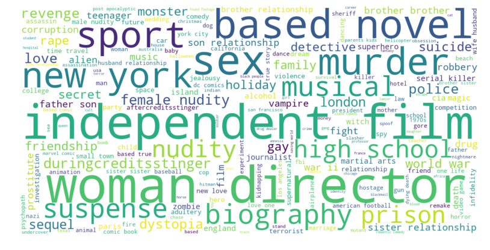

```python
fig, ax = plt.subplots(figsize=(15,7))
plt.imshow(wordcloud, interpolation='bilinear')
plt.axis("off");
```

### 6. What kinds of properties are associated with movies that have high revenues?

```python
df.corr()['revenue_adj']
```

```
id             -0.138487
popularity      0.609085
budget          0.622531
revenue         0.919109
runtime         0.175668
vote_count      0.707941
vote_average    0.193062
release_year   -0.066236
budget_adj      0.646627
revenue_adj     1.000000
profit_adj      0.008873
Name: revenue_adj, dtype: float64
```

> **We see that the popularity, the budget and the vote_count are positively correlated with the revenue of a movie.**

### 7. Does Sex really sell?

```python
# based on our word cloud, we derive keywords which hint at sex or nudity in the movies
sexy_keywords = ["sex", "nudity", "female nudity", "male nudity", "prostitute"]
movies_with_sex = df_keywords[df_keywords['keywords'].isin(sexy_keywords)]

# adding a nudity column
df['nudity'] = df_test['id'].isin(movies_with_sex['id'])
```

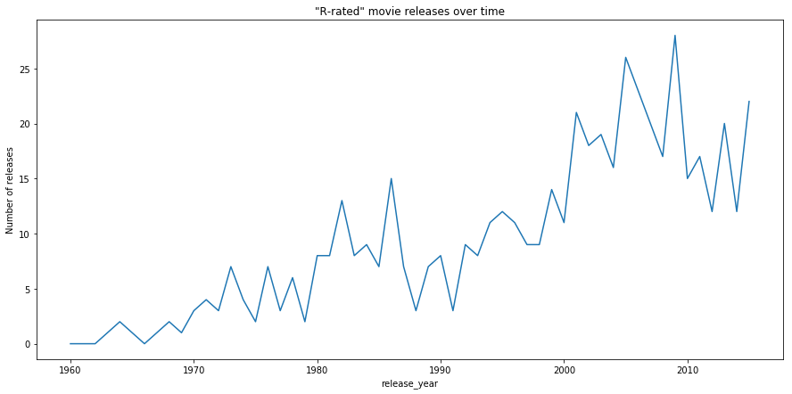

```python
#lets plot the number of film releases with nudity over time
fig, ax = plt.subplots(figsize=(15,7))
plt.title('"R-rated" movie releases over time')
plt.ylabel("Number of releases")
df.groupby('release_year')['nudity'].sum().plot()
```

> **As we cans see films with nudity are much more common today then 50 years ago!**

```python
# calculating the average revenues of films with nudity
df.query('nudity')['revenue_adj'].mean()
```

```
28833194.05150653
```

```python
# and without nudity
df.query('not nudity')['revenue_adj'].mean()
```

```
52513227.97222285
```

> **As we can see from the average revenues, the theory "sex sells" does not hold. The average revenue of films with nudity is lower then the average revenue of films without revenue. Of course this is no real statistical analysis. Inorder to so one would need to calculate the correlation between the revenue and the nudity category. Pearsons correlations coefficient is not suitable here.**

## Conclusions

Please visit the subsections of the research questions to find the full answers to the proposed questions!

#### 1. What are the Top-10 rates movies of all time?

The most popular movie is the The Shawshank Redemption, followed by The Godfather and Whiplash on 3rd. See the full list in the subsection.

#### 2. Which genres are most popular from year to year?

There is a sharp increase in popularity of Adventure and Western movies in the last years. See the full chart in the subsection.

#### 3. Which genre is the most profitable one?

The "Family" genre.

#### 4. Who is the most popular actor?

Samuel L. Jackson.

#### 5. Generating a wordcloud from keywords

See subsection.

#### 6. What kinds of properties are associated with movies that have high revenues?

We see that the popularity, the budget and the vote_count are positively correlated with the revenue of a movie.

#### 7. Does sex really sell?

Movies which include nudity have vastly increased over time. However, the average revenues do not seem to indicate that these movies generally make more money. Further statistical analysis could be performed to confirm these findings.

### Resources used in this submission:

Creating matplotlib line graphs: http://www.randalolson.com/2014/06/28/how-to-make-beautiful-data-visualizations-in-python-with-matplotlib/

Seperating data in columns: https://stackoverflow.com/questions/14745022/how-to-split-a-column-into-two-columns + a combination of slack searches. @Randy Jacksons posts were particulary helpfull

Creating word clouds: https://stackoverflow.com/questions/43606339/generate-word-cloud-from-single-column-pandas-dataframe